# Life Expectancy Analysis

Feature selection is the process of selecting the most important features from a dataset for use in a machine learning model. There are many different feature selection methods, but two of the most common are backward and forward selection. This project will use backward and forward selection to select the most important features from the dataset for use in the machine learning model.

```r
library(leaps)
regfit.bwd <- suppressWarnings(regsubsets(Life.expectancy~.,data=df,nvmax=16,method="backward"))
```

```
## Reordering variables and trying again:
```

```r
bwd.summary <- summary(regfit.bwd)
```

```r
regfit.fwd <- suppressWarnings(regsubsets(Life.expectancy~.,data=df,nvmax=16,method="forward"))
```

```
## Reordering variables and trying again:
```

```r
fwd.summary <-summary(regfit.fwd)
```

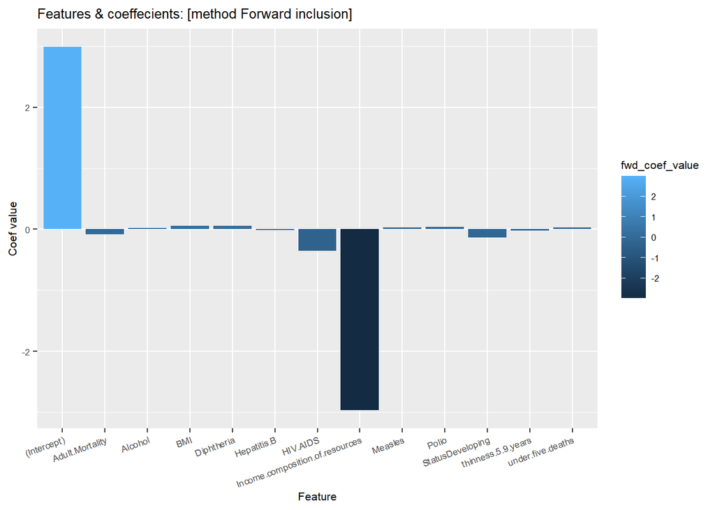

```r
v_names <- rownames(as.data.frame(coef(regfit.fwd,12)))
coefs<- data.frame(v_names)
coefs$fwd_coef_value <-  coef(regfit.fwd,12)
coefs$bwd_coef_value <-  coef(regfit.bwd,12)

set_plot_dimensions(18,4)
ggplot(coefs,
       aes(x=v_names, y=fwd_coef_value, fill=fwd_coef_value)) +
                                  geom_bar(stat="identity") +
                                  ggtitle("Features & coeffecients: [method Forward inclusion]") +
                                  xlab("Feature") + ylab("Coef value") +
                                  theme(axis.text.x=element_text(angle=20, hjust=1))+
                                  theme(text = element_text(size = 8))
```

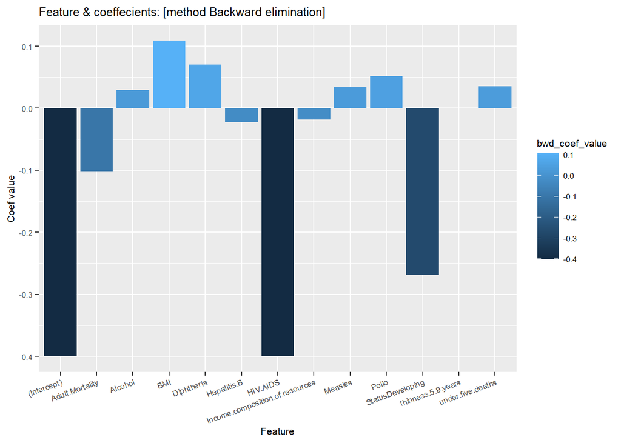

```r
ggplot(coefs,
       aes(x=v_names, y=bwd_coef_value, fill=bwd_coef_value)) +
                                  geom_bar(stat="identity") +
                                  ggtitle("Feature & coeffecients: [method Backward elimination]") +
                                  xlab("Feature") + ylab("Coef value") +
                                  theme(axis.text.x=element_text(angle=20, hjust=1))+
                                  theme(text = element_text(size = 8))
```

Based on the plot above choose the same 12 variables. In the next step we will perform linear regression on full model and on the 12 variables from feature selection.

```r
#Split train and test data

sample <- sample(c(TRUE, FALSE), nrow(df), replace=TRUE, prob=c(0.70,0.30))
train <- df[sample, ]
x.test <-df[!sample, ]
y.test <- df[!sample, ]$Life.expectancy
```

1. Linear Regression with all variables

```r
model1<- lm(Life.expectancy~., data = train)
summary(model1)
```

```
##
## Call:
## lm(formula = Life.expectancy ~ ., data = train)
##
## Residuals:
##     Min      1Q  Median      3Q     Max
## -3.2846 -0.2211  0.0090  0.2452  2.1184
##
## Coefficients: (1 not defined because of singularities)
##                                  Estimate Std. Error t value Pr(>|t|)
## (Intercept)                      2.964596   0.177131  16.737  < 2e-16 ***
## StatusDeveloping                -0.120833   0.033842  -3.571 0.000364 ***
## Adult.Mortality                 -0.081040   0.010669  -7.596 4.63e-14 ***
## Alcohol                          0.016680   0.003208   5.199 2.21e-07 ***
## Hepatitis.B                     -0.019266   0.010769  -1.789 0.073760 .
## Measles                          0.030417   0.012491   2.435 0.014974 *
## BMI                              0.053658   0.012152   4.416 1.06e-05 ***
## under.five.deaths                0.027910   0.010978   2.542 0.011082 *
## Polio                            0.046822   0.011563   4.049 5.33e-05 ***
## Total.expenditure               -0.003078   0.010339  -0.298 0.765937
## Diphtheria                       0.046094   0.012396   3.719 0.000206 ***
## HIV.AIDS                        -0.360138   0.007704 -46.747  < 2e-16 ***
## Population                      -0.018919   0.009900  -1.911 0.056143 .
## thinness.5.9.years                     NA         NA      NA       NA
## Income.composition.of.resources -2.951022   0.151041 -19.538  < 2e-16 ***
## ---
## Signif. codes:  0 '***' 0.001 '**' 0.01 '*' 0.05 '.' 0.1 ' ' 1
##
## Residual standard error: 0.4374 on 2045 degrees of freedom
## Multiple R-squared:  0.8097, Adjusted R-squared:  0.8085
## F-statistic: 669.3 on 13 and 2045 DF,  p-value: < 2.2e-16
```